# COMPSCIX 415.2 Homework 9/Final

Emerson Sosa

3/30/2019

# Exercise 1 - Sampling Distributions, Functions and For Loops

### Step 1

Write an R function that does the following:

- Takes a sample of size samp_size from this exponential distribution (samp_size is an input parameter for the function)
- Calculates the mean of that sample
- Calculates the standard deviation of that sample
- Returns the calculated mean and standard deviation as a list

```r
# sample size
samp_size <- 100

# set the rate parameter
samp_rate <- 1/10000

# take sample
samp.output <- rexp(n = samp_size, rate = samp_rate)


samp_fun <- function(samp_size, samp_rate) {
  samp.output <- rexp(n = samp_size, rate = samp_rate)
  samp_avg <- mean(samp.output)
  samp_std_dev <- sd(samp.output)
  stats <- list(samp_avg = samp_avg, samp_std_dev = samp_std_dev)
  return(stats)
}

samp_fun(100, 1/10000)
```

```
## $samp_avg
## [1] 10388.28
##
## $samp_std_dev
## [1] 12044.42
```

### Step 2

Then write a loop that does this:

- Runs the above function 1000 times, with samp_size = 50 and samp_rate = 1/10000
- Saves all of the sample means in a vector called sample_means, and all of the sample standard deviations in a vector called sample_sds

```r
# sample size
#samp_size <- 50

# set the rate parameter
#samp_rate <- 1/10000

# take sample



#samp_fun <- function(samp_size, samp_rate) {
 # samp.output <- rexp(n = samp_size, rate = samp_rate)
  #samp_avg <- mean(samp.output)
  #samp_std_dev <- sd(samp.output)
  #stats <- list(samp_avg = samp_avg, samp_std_dev = samp_std_dev)
  #return(stats)
#}
#samp_fun(40,1/10000)

#samp_avg

#my_mods <- my_samps <- list() # empty lists for saving models and samples
#for(i in 1:n) {

# create space for the output of your loop
#n <- 4
#sample_means <- rep(NA, n)
#sample_sds <- rep(NA, n)
#samp_fun_all <- rep(NA, n)

# start the loop
#for(i in 1:n) {
 # samp_fun_all[i] <-  samp_fun(50, 1/10000)
  #full.stats <- list(samp_fun_all = samp_fun_all)
#}
#samp_fun_all
#  ...
 # output_vector[index] <- output # save the output for each iteration
#}
```

# Exercise 2 - Linear Regression

Load the train.csv dataset into R and fit a regression model with:

- y = SalePrice
- Features: LotArea, OverallQual, and ExterQual

```r
library(broom)
train.data <-
  read_csv('train.csv')

#Analyzing regression model for SalePrice, LotArea, OverallQual, ExerQual.
house.mult.lm <- lm(SalePrice ~ LotArea + OverallQual + ExterQual, data = train.data)

tidy(house.mult.lm)
```

```
## # A tibble: 6 x 5
##   term         estimate std.error statistic   p.value
##   <chr>           <dbl>     <dbl>     <dbl>     <dbl>
## 1 (Intercept)  40764.   12358.         3.30 9.95e-  4
## 2 LotArea          1.45     0.116     12.5  3.72e- 34
## 3 OverallQual  34466.    1216.        28.3  4.77e-141
## 4 ExterQualFa -95352.   14592.        -6.53 8.80e- 11
## 5 ExterQualGd -71529.    6737.       -10.6  2.05e- 25
## 6 ExterQualTA -97527.    7541.       -12.9  2.72e- 36
```

```r
glance(house.mult.lm)
```

```
## # A tibble: 1 x 11
##   r.squared adj.r.squared  sigma statistic p.value    df  logLik    AIC
##       <dbl>         <dbl>  <dbl>     <dbl>   <dbl> <int>   <dbl>  <dbl>
## 1     0.695         0.694 43948.      663.       0     6 -17677. 35368.
## # … with 3 more variables: BIC <dbl>, deviance <dbl>, df.residual <int>
```

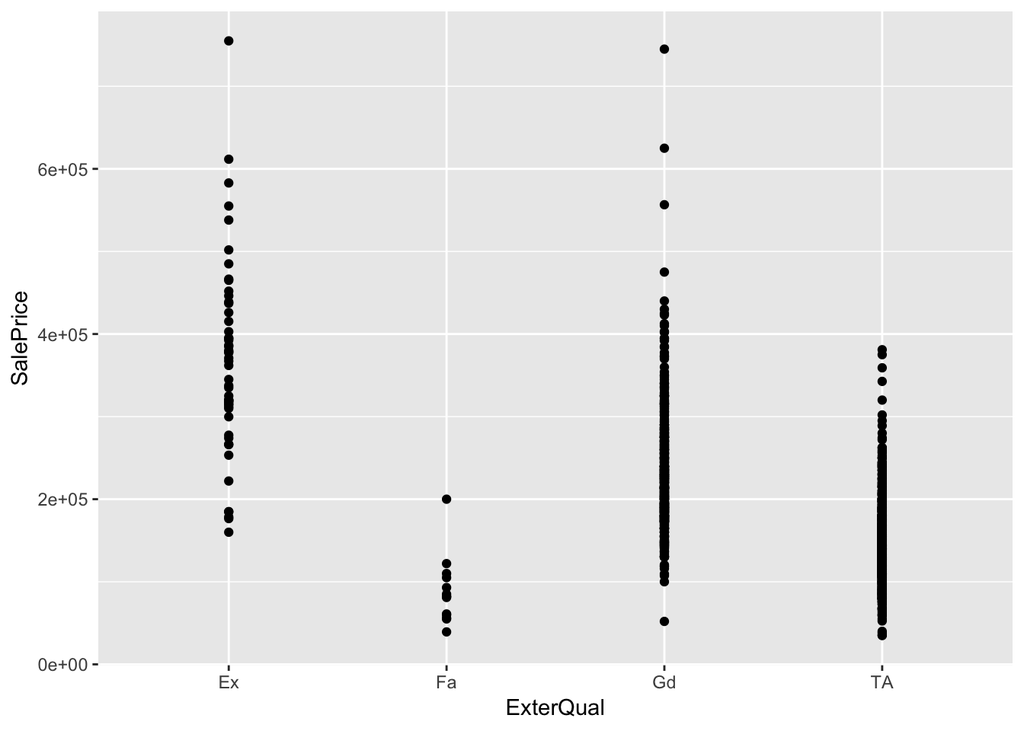

```r
ggplot(train.data) +
  geom_point(aes(ExterQual, SalePrice))
```

```r
#Analyzing regression model from Homework 7.
train.mult.lm <- lm(formula = SalePrice ~ OverallQual + GrLivArea + Neighborhood, data = train.data)

tidy(train.mult.lm)
```

```
## # A tibble: 27 x 5
##    term                estimate std.error statistic  p.value
##    <chr>                  <dbl>     <dbl>     <dbl>    <dbl>
##  1 (Intercept)         -34829.   11541.       -3.02 2.59e- 3
##  2 OverallQual          20951.    1162.       18.0  1.24e-65
##  3 GrLivArea               55.6      2.50     22.2  2.38e-94
##  4 NeighborhoodBlueste -30753.   27697.       -1.11 2.67e- 1
##  5 NeighborhoodBrDale  -43359.   12979.       -3.34 8.57e- 4
##  6 NeighborhoodBrkSide -13025.   10450.       -1.25 2.13e- 1
##  7 NeighborhoodClearCr  24576.   11570.        2.12 3.38e- 2
##  8 NeighborhoodCollgCr  11414.    9497.        1.20 2.30e- 1
##  9 NeighborhoodCrawfor  14444.   10502.        1.38 1.69e- 1
## 10 NeighborhoodEdwards -17843.    9986.       -1.79 7.42e- 2
## # … with 17 more rows
```

```r
glance(train.mult.lm)
```

```
## # A tibble: 1 x 11
##   r.squared adj.r.squared  sigma statistic p.value    df  logLik    AIC
##       <dbl>         <dbl>  <dbl>     <dbl>   <dbl> <int>   <dbl>  <dbl>
## 1     0.787         0.783 37009.      203.       0    27 -17416. 34887.
## # … with 3 more variables: BIC <dbl>, deviance <dbl>, df.residual <int>
```

Use the broom package to output the coefficients and the R-squared

Coefficients and R-Squared are in the outputted tibbles above.

Interpret the coefficient on LotArea

The coefficient for LotArea is 1.452925. In other words, for every one unit increase in lot size in square feet, the price increases, on average, by $1.45.

Interpret the coefficient on ExterQualGd

The coefficient for ExterQualGd is -71529.49. In other words, for every one unit increase in the external quality being graded as ‘Good’, the price decreases, on average, by $71,529. This makes sense as the reference point is external quality being Excellent. Anything under would decrease in price.

Compare this model to the model we fit in HW 7 with GrLivArea, OverallQual, Neighborhood. Which is the better fitting model?

Using R squared as our rationale for deciding which is the better fit, HW 7’s R adjusted squared (used when there are more than one variable) is *0.782981* and the model asked to be analyzed in this homework assignment is *0.693963*. As theorized in class, an R Squared value that is closer to one is a better fit so it would seem that the model used in HW 7 is better than the one built in this assignment.

# Exercise 3 - AB Testing

What proportion of visitors converted for each version of the webpage?

Conversion rate for Version A is 4.15%. Conversion rate for Version B is 10%.

Perform the AB test in R. What is the p-value for the AB test (hypothesis test of proportions)?

```r
ab.data <-
  read_csv('ab_test_data.csv')


group.ab.data <- ab.data %>%
  count(version, conversion == 1)

group.ab.data
```

```
## # A tibble: 4 x 3
##   version `conversion == 1`     n
##   <chr>   <lgl>             <int>
## 1 A       FALSE              1917
## 2 A       TRUE                 83
## 3 B       FALSE              1800
## 4 B       TRUE                200
```

```r
# Conversion rate for Version A
true.a <- 83/2000

n.a <- 2000

#Conversion rate for Version B
true.b <- 200/2000

n.b <- 2000

samp.a <- rbinom(n = 1, size = n.a, prob = true.a)
samp.b <- rbinom(n = 1, size = n.b, prob = true.b)
two_prop_test <- prop.test(c(samp.a, samp.b), c(2000, 2000))
two_prop_test$p.value
```

```
## [1] 2.323694e-15
```